# Sample Proportions

TEMBA Statistics 2026

## Human or AI?

A marketing team shows customers two ads for the same product, one written by a person and one by AI.

Customers see the ads in random order, without author labels, and choose which one they think AI wrote.

In this invented study, **531 of 1,100 customers choose correctly**.

How accurately can customers identify the AI-written ad?

## A sample proportion

Record each response as 1 for correct and 0 for incorrect.

The **sample proportion** is the mean of those zeros and ones:

$$\hat p=\frac{\text{number correct}}{\text{number of customers}}
=\frac{531}{1{,}100}\approx 0.483.$$

It estimates $p$, the proportion of this company’s customers who would identify the AI-written ad in this pair.

## Standard error

Treat the responses as independent draws from this company’s customers.

$$SE(\hat p)=\sqrt{\frac{p(1-p)}{n}}
\approx\sqrt{\frac{\hat p(1-\hat p)}{n}}.$$

$$\widehat{SE}=\sqrt{\frac{0.4827(1-0.4827)}{1{,}100}}
\approx 0.0151.$$

The estimate typically varies by about **1.5 percentage points** across samples.

## A confidence interval

The approximate 95% interval is the estimate plus or minus two standard errors:

$$0.4827\pm2(0.01507)
\approx[0.453,\ 0.513].$$

Under the sampling model, accuracy from about **45.3% to 51.3%** is plausible.

## Assessing a particular value

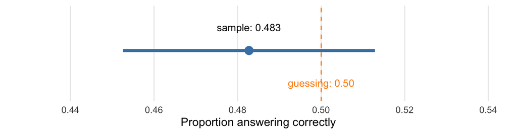

The interval includes $p=0.50$. How unusual would our estimate be if that value were true?

A **hypothesis test** measures the evidence against a specified population value.